# BIN_SVM

Les SVM, machines à vecteurs de support, sont un ensemble de techniques d’apprentissage supervisé destinées à résoudre des problèmes de discrimination et de régression. Les SVM sont une généralisation des classifieurs linéaires. Ces classificateurs reposent sur deux idées clés, qui permettent de traiter des problèmes de discrimination non linéaire, et de reformuler le problème de classement comme un problème d’optimisation quadratique. La première idée clé est la notion de marge maximale. La marge est la distance entre la frontière de séparation et les échantillons les plus proches. Ces derniers sont appelés vecteurs supports. Dans les SVM, la frontière de séparation est choisie comme celle qui maximise la marge.

# Installation des packages et Chargement des librairies

```r
# install.packages("e1071")
library(e1071) # Pour le SVM

# install.packages("pROC")
library(pROC) # Pour le calcul de l'AUC
#install.packages("Epi")
library(Epi) # Pour la courbe ROC
```

# Chargement des donnees

```r
setwd("C:/Users/sophie/Documents/Projet_SNCF")
TAB_bis <- read.csv2("TAB_bis.csv", header=TRUE, sep=";")
BASE_Multi_TRAIN <- read.csv2("BASE_Multi_TRAIN.csv",sep=";",header=T)
BASE_Multi_TEST  <- read.csv2("BASE_Multi_TEST.csv",sep=";",header=T)

X = BASE_Multi_TRAIN[,c("Class_Binaire","Profil","VITESSE","AGE","TYPE_RAYON_COURBE","TRAIN","UIC")]
X$Class_Binaire <- as.factor(X$Class_Binaire)
```

# création de la fonction cross validation

```r
rownames(X)<-NULL
X_O<-X[which(X$Class_Binaire=="0"),]
X_1<-X[which(X$Class_Binaire=="1"),]

rownames(X_O)<-NULL
rownames(X_1)<-NULL

CROSS<-function(X){

  set.seed(1444)
  ID<-sample(1:nrow(X),nrow(X))
  a<- seq(1,nrow(X),round((nrow(X)/10))+1)
  X$fold<-10

  for (i in 1:9){
    X$fold[ID[a[i]:(a[i+1]-1)]]<-i
    }

  return(X)

}

X_O<-CROSS(X_O)
X_1<-CROSS(X_1)

X_fin<-rbind(X_O,X_1)
X_fin<-X_fin[order(X_fin$fold),]

rownames(X_fin)<-NULL
rownames(X_fin)<-NULL
```

# fonction performance en 10fold contenant modele SVM et prediction et retourne le taux d’erreur

```r
performances <- c()

# Création de la boucles sur les 10 folders

for (i in 1:10){
    # Train qui contient 9 blocs
    training_set <- X_fin[X_fin$fold != i,]
    # test qui contient 1 bloc
    testing_set <-  X_fin[X_fin$fold == i,]

  ##  model
  model<- svm(Class_Binaire ~ ., data = training_set)

  ## Test model
  # summary(model)

  # Predict
  predicted <- predict(model, testing_set)

  ## changer les proba en indicateurs
  model_prob<- svm(Class_Binaire ~ ., data = training_set,probability = TRUE)
  predicted_prob <- predict(model_prob, testing_set, probability=TRUE)

  ## la matrice de confusion
  confmat = table(predicted,testing_set$Class_Binaire)

  # K<-xtabs(....)

  K <- xtabs(~predicted+testing_set$Class_Binaire)
  ftable(K)

  # calcule de l'erreur

  confmat = table(predicted,testing_set$Class_Binaire)
  ERREUR_MOD<-1-sum(diag(confmat))/sum(confmat)

  # Ajouter à la liste ->> à la fin on obtient 10 : on les moyenne

  performances[i] <- ERREUR_MOD
}

c('ERREUR' = mean(performances))
```

```
## ERREUR
## 0.3098
```

ERREUR 0.3098

```r
confmat
```

```
##
## predicted   0   1
##         0 573 258
##         1   8  24
```

```r
confmat_prob = table(predicted_prob,testing_set$Class_Binaire)
```

confmat matrice de confusion : predicted 0 1 0 573 258 1 8 24

```
    confmat_prob :
```

predicted_prob 0 1 0 570 253 1 11 29

```r
# Matrice de confusion associÃ© au modÃ¨le
confusion <- addmargins(confmat_prob)


# Calcul de la moyenne des bien predits sur le train :
perf <- (mean(predicted_prob==testing_set$Class_Binaire) )
# Calcul du taux de Faux positifs (TFP) :
TFP <- confusion[2,1]/confusion[3,1]
# Calcul du taux de Faux negatifs (TFN) :
TFN <- confusion[1,2]/confusion[3,2]

# Affichage :
  confusion
```

```
##
## predicted_prob   0   1 Sum
##            0   570 253 823
##            1    11  29  40
##            Sum 581 282 863
```

```r
  print(c('Performance' = perf))
```

```
## Performance
##   0.6940904
```

```r
  print(c('TFP' = TFP))
```

```
##        TFP
## 0.01893287
```

```r
  print(c('TFN' = TFN))
```

```
##       TFN
## 0.8971631
```

predicted_prob 0 1 Sum 0 570 253 823 1 11 29 40 Sum 581 282 863

Performance 0.6940904

```
   TFP
```

0.01893287

TFN 0.8971631

### Courbe ROC sur le TEST :

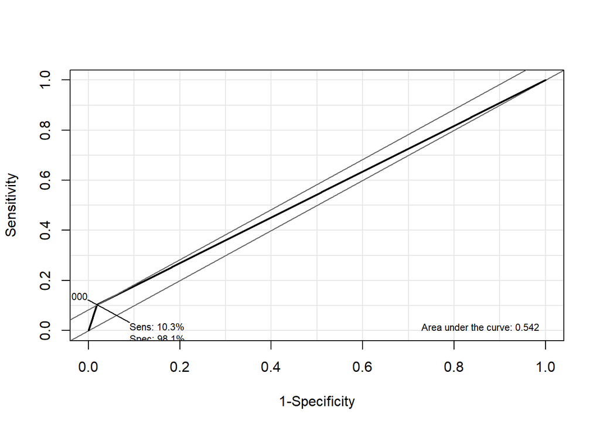

```r
Epi::ROC(test = predicted_prob,
    stat = testing_set$Class_Binaire,
    data = testing_set, plot = "ROC", MI=F)
```